# Greener_Houses

[figure not shown]

**Explanatory Data Analysis to Build some Buy&Sell House Company Insights**

Greener Houses is an 8 yrs company with a business model focused on **buying** and **selling** houses through its digital platform. It is a very technological company and it performs all services based on market analysis decision making.

But as time goes by, Greener Houses has been noticing that its profits and incomes haven't increased since their last big negotiation seven months ago.

Holding this important role as a technological symbol in the market, the company decided it was time to hire a *Data Scientist* to analyze the situation and to come up with better **insights** and **business opportunities** on the house market. The CEO is very proud of his idea and is counting on finding a professional very well qualified to help him increase Greener Houses revenue.

The company's main strategy is to buy some good standard houses in attractive locations at low prices, and then sell these houses at higher prices. The more the difference between buying and selling, the higher the company's profit on the deal; thus, the business revenue increases. However, that is not as simple as it sounds. Houses have many attributes which could turn them into great deals or not for both buyers and sellers. Location and period of the year (summer or winter, for instance) could also directly affect the houses pricing.

And that is where a Data Scientist will greatly come in handy for Greener Houses businesses to come.

**Table of Contents**

1. Business and Analysis Understanding

   > Business Problem  
   > Business Assumptions  
   > Dataset Description  
   > Solution Planning  
   > Hypothesis
2. Imports
3. Descriptive Analysis
4. Data Cleaning and Preparation
5. Exploratory Data Analysis

   > Business Problem Nº1  
   > Business Problem Nº2
6. Communicating Results

   > Evaluating Hypothesis  
   > Graphical Data Visualization
7. Conclusion

### Business and Analysis Understanding

#### Business Problem

There are still some important bullet points about Greener Houses we must take into consideration. The CEO has been very clear about their strategies and he doesn't accept revenues losses. Also, he expects to receive some valuable insights that can be useful and **quickly applicable**. This way, to come into a solution for the company's business, there are three core questions to be answered:

- Which houses should Greener Houses buy and how much should the company pay for them?
- Once the house is acquired, when should it be sold and at what price?
- Should Greener Houses renovate a house to increase the sale price?

At the very end, Greener Houses will receive a final report with all the renovation, buying, and selling recommendations, along with the description of the decision making.

#### Business Assumptions

It is not unusual that we face outliers on datasets. Outliers are observations that lie a notable difference from other observations. In other words, an outlier can be defined as a data point that differs significantly from other values in a random sample from a population. Outliers may cause serious problems in statistical analyses due to the unexpected variability they reflect in many statistical measures. Thereby, these so-called errors are sometimes excluded from the dataset.

However, it is very important to understand the reason for these outliers to be there in the first hand because not always an outlier will be seen as an error, since it could merely be a reflection from seasonality, for example. Consequently, it is also the data scientist role to identify these outliers, to define the reasons for their appearance, and to decide if they should be considered abnormal, meaning they would be excluded or not from the statistical analysis.

**IQR Method of Outlier Detection**

For Greener Houses business problems applied the IQR method to detect outliers on the dataset the company provided. This method consists in finding the Inter-Quartile Range (IQR), and then calculating the Lower and Upper Bounds to determine the values that will be considered as outliers or not. To have a better understanding on this outlier detection method, here are some useful definitions:

- *minimum*: is the minimum value in the dataset for the target variable.
- *maximum*: is the maximum value in the dataset for the target variable.
- *Q1*: is the first quartile of the data, i.e., to say 25% of the data lies between minimum and Q1.
- *median*: also called the second quartile, it is the center point (the median) of the data, considering an ordered set of data. It is to say 50% of the data lies below median and the other half lies above median.
- *Q3*: is the third quartile of the data, i.e., to say 75% of the data lies between minimum and Q3.

The difference between *Q3* and *Q1* is called the **Inter-Quartile Range** or simply **IQR**.

```
   IQR = Q3 - Q1
```

After defining the IQR range, we created new boundaries that we called decision ranges, where any point lying outside these ranges were considered as outliers. They were as given below:

```
   Lower Bound: (Q1 - 1.5 * IQR)
   Upper Bound: (Q3 + 1.5 * IQR)
```

This way, any data more than the *Upper Bound* or less than the *Lower Bound* were considered as an outlier.

#### Dataset Description

Greener Houses provided a dataset containing houses sale prices and many attributes for each one of them. This is where the company wants to start evaluating the opportunities and it is important to understand what this data tell us about the houses pricing.

| Atributte | Type | Description |
| --- | --- | --- |
| id | Integer | Unique ID for each home sold. |
| date | Object | Date of the home sale. |
| price | Float | Price of each home sold. |
| bedrooms | Integer | Number of bedrooms. |
| bathrooms | Float | Number of bathrooms, where .5 accounts for a room with a toilet but no shower. |
| sqft_living | Integer | Square footage of the apartments interior living space. |
| sqft_lot | Integer | Square footage of the land space. |
| floors | Float | Number of floors. |
| waterfront | Integer | A dummy variable for whether the apartment was overlooking the waterfront or not. |
| view | Integer | An index from 0 to 4 of how good the view of the property was. |
| condition | Integer | An index from 1 to 5 on the condition of the apartment. |
| grade | Integer | An index from 1 to 13, where 1-3 falls short of building construction and design, 7 has an average level of construction and design, and 11-13 have a high quality level of construction and design. |
| sqft_above | Integer | The square footage of the interior housing space that is above ground level. |
| sqft_basement | Integer | The square footage of the interior housing space that is below ground level. |
| yr_built | Integer | The year the house was initially built. |
| yr_renovated | Integer | The year of the house’s last renovation. |
| zipcode | Integer | What zipcode area the house is in. |
| lat | Float | Lattitude. |
| long | Float | Longitude. |
| sqft_living15 | Integer | The square footage of interior housing living space for the nearest 15 neighbors. |
| sqft_lot15 | Integer | The square footage of the land lots of the nearest 15 neighbors. |

#### Solution Planning

To come up with a solution, we will need to analyze how the houses prices are affected by each attribute presented on the company's dataset. With this understanding, it'll be possible to answer the business problem questions and also to evaluate some hypothesis created upon the data.

But it is very important to make a solution planning prior to start analyzing the data, and that is because a it allows us to see the steps we need to take to find the results wee seek. A solution planning is nothing more than our goals roadmap. With that having said, here are the steps we'll take for each question to be answered:

**1. To suggest buying or not buying a house.**

- Collecting data;

- Grouping data per region (zipcode);

- Finding the houses prices median for each region;

- Suggesting to buy the houses in good conditions that have prices lower than the median of its region.

Each region has its specific set of considerations for pricing the houses. It means that it wouldn't be very accurate to directly compare prices for houses in different regions, even though they have the same attributes. With this in mind, the houses will be first separated by region, represented by its zipcodes. Then, the median will be the value for which houses prices are split in two halves: the 50% below and the 50% above the median. Finally, the houses in good conditions and priced below the median value will have a Buy status. On the other hand, houses priced above the median will have a Not to buy status.

Some set of conditions will be up to be evaluated prior to the final decision and so the house will hold an On Hold status up to this moment. This status will then be changed on the next few steps. For instance, houses in poorly conditions and priced way below the median would have to be carefully evaluated to see if it's worthy to buy and renovate it or not.

**2. To suggest when to sell and at what price.**

- Organizing data;

- Grouping data per region (zipcode) and seasonality;

- Finding the houses prices median within each set of region and seasonality;

| Selling suggestions |  |
| --- | --- |
| If the buying price is **lower** than the median for the corresponding region and seasonality, the selling price should be equal to the purchase value with a plus of **30%/**. |  |
| If the buying price is **higher** than the median for the corresponding region and seasonality, the selling price should be equal to the purchase value with a plus of **15%**. |  |

If Greener Houses gets to buy a house cheaper than the corresponding median region and seasonality, a suggested selling price is to increase in 30% the amount paid for the purchase. That is because sometimes good houses can be sold at lower prices if the owner needs to make a deal in a rush. This way, the company can go for a higher markup.

#### Hypothesis

Business hypothesis are assumption that the value proposition and strategy builds on. In other words, they are all the things that would have to be true for the business idea to work. We will test these hypothesis and, as a result, support or reject them; these might help us having insights about the business other than only answering the business problems. They are evaluated under the section Evaluating Hypothesis, right after the main business problems are analyzed.

- **H1**: houses overlooking the waterfront are 30% more expensive, on average.
- **H2**: houses with a construction date prior to 1995 are 50% cheaper, on average.
- **H3**: houses with 2 bathrooms are 35% cheaper than houses with 3 bathrooms, on average.
- **H4**: houses with grades 9 or higher are 75% more expensive than houses with grades 7 or lower, on average.
- **H5**: houses with basements have a total area (sqrt lot) 40% larger than houses without basements.
- **H6**: houses with 3 bathrooms have a MoM (Month over Month) positive growth within time.

### 1. Imports

Importing packages and functions:

```python
# data analysis and manipulation
import pandas as pd

# mathematical operations
import numpy as np

# data visualization
import matplotlib.pyplot as plt
import seaborn as sns
%matplotlib inline

# warnings
import warnings
warnings.filterwarnings('ignore')
```

Loading the dataset into a pandas dataframe:

```python
df = pd.read_csv('kc_house_data.csv')
df
```

|  | id | date | price | bedrooms | bathrooms | sqft_living | sqft_lot | floors | waterfront | view | ... | grade | sqft_above | sqft_basement | yr_built | yr_renovated | zipcode | lat | long | sqft_living15 | sqft_lot15 |
| --- | --- | --- | --- | --- | --- | --- | --- | --- | --- | --- | --- | --- | --- | --- | --- | --- | --- | --- | --- | --- | --- |
| 0 | 7129300520 | 20141013T000000 | 221900.0 | 3 | 1.00 | 1180 | 5650 | 1.0 | 0 | 0 | ... | 7 | 1180 | 0 | 1955 | 0 | 98178 | 47.5112 | -122.257 | 1340 | 5650 |
| 1 | 6414100192 | 20141209T000000 | 538000.0 | 3 | 2.25 | 2570 | 7242 | 2.0 | 0 | 0 | ... | 7 | 2170 | 400 | 1951 | 1991 | 98125 | 47.7210 | -122.319 | 1690 | 7639 |
| 2 | 5631500400 | 20150225T000000 | 180000.0 | 2 | 1.00 | 770 | 10000 | 1.0 | 0 | 0 | ... | 6 | 770 | 0 | 1933 | 0 | 98028 | 47.7379 | -122.233 | 2720 | 8062 |
| 3 | 2487200875 | 20141209T000000 | 604000.0 | 4 | 3.00 | 1960 | 5000 | 1.0 | 0 | 0 | ... | 7 | 1050 | 910 | 1965 | 0 | 98136 | 47.5208 | -122.393 | 1360 | 5000 |
| 4 | 1954400510 | 20150218T000000 | 510000.0 | 3 | 2.00 | 1680 | 8080 | 1.0 | 0 | 0 | ... | 8 | 1680 | 0 | 1987 | 0 | 98074 | 47.6168 | -122.045 | 1800 | 7503 |
| ... | ... | ... | ... | ... | ... | ... | ... | ... | ... | ... | ... | ... | ... | ... | ... | ... | ... | ... | ... | ... | ... |
| 21608 | 263000018 | 20140521T000000 | 360000.0 | 3 | 2.50 | 1530 | 1131 | 3.0 | 0 | 0 | ... | 8 | 1530 | 0 | 2009 | 0 | 98103 | 47.6993 | -122.346 | 1530 | 1509 |
| 21609 | 6600060120 | 20150223T000000 | 400000.0 | 4 | 2.50 | 2310 | 5813 | 2.0 | 0 | 0 | ... | 8 | 2310 | 0 | 2014 | 0 | 98146 | 47.5107 | -122.362 | 1830 | 7200 |
| 21610 | 1523300141 | 20140623T000000 | 402101.0 | 2 | 0.75 | 1020 | 1350 | 2.0 | 0 | 0 | ... | 7 | 1020 | 0 | 2009 | 0 | 98144 | 47.5944 | -122.299 | 1020 | 2007 |
| 21611 | 291310100 | 20150116T000000 | 400000.0 | 3 | 2.50 | 1600 | 2388 | 2.0 | 0 | 0 | ... | 8 | 1600 | 0 | 2004 | 0 | 98027 | 47.5345 | -122.069 | 1410 | 1287 |
| 21612 | 1523300157 | 20141015T000000 | 325000.0 | 2 | 0.75 | 1020 | 1076 | 2.0 | 0 | 0 | ... | 7 | 1020 | 0 | 2008 | 0 | 98144 | 47.5941 | -122.299 | 1020 | 1357 |

21613 rows × 21 columns

The data shape is (21613 rows x 21 columns). It means that it has 21613 registered houses and 21 attributes for each one of them.

### 2. Descriptive Analysis

Descriptive analysis is the stage at which we become familiar with the data. It allows us to have a better understanding of the data we are manipulating, and to answer questions like "What is happening?", helping decision makers to make decisions right away. Also, it is represented by brief descriptive coefficients that **summarize** a given set of data, which can be either a representation of the entire or a sample of a population.

Usually, descriptive analysis might be useful for two main purposes:

1. To provide basic information about variables in a dataset;
2. And to highlight potential relationships between variables.

Besides that, it can be broken down into three types of measures:

- **Measures of Central Tendency**: describe the "average" member of the population of interest. They include:

- **Mean**: the sum of a variable's values divided by the total number of values.

- **Median**: the middle value of a variable.

- **Mode**: the value that occurs most often.

- **Measures of Variability (Dispersion)**: provide information about the spread of data. They include:

- **Range**: the difference between the smallest and largest values in the data.

- **Variance**: the most commonly used measure of dispersion. It is calculated by taking the average of the squared differences between each value and the mean.

- **Standard Deviation**: the square root of the variance.

- **Measures of Association**: indicate whether two variables are related.

- **Correlation**: to measure the strength of the relationship between numeric variables.

These are some of the statistical parameters available to describe a dataset, but they are not the only ones. Finally, most of the descriptive analysis results are displayed graphically.

- Checking the data types
- Checking for missing values
- Checking for duplicated values
- Changing data types, if needed
- Performing a descriptive statistics

```python
# data types
df.dtypes
```

```
id                 int64
date              object
price            float64
bedrooms           int64
bathrooms        float64
sqft_living        int64
sqft_lot           int64
floors           float64
waterfront         int64
view               int64
condition          int64
grade              int64
sqft_above         int64
sqft_basement      int64
yr_built           int64
yr_renovated       int64
zipcode            int64
lat              float64
long             float64
sqft_living15      int64
sqft_lot15         int64
dtype: object
```

For the purpose of this data analysis, there will be no need for changing data types at this moment. The attribute `date` will have its type modified later on for the sections to come.

```python
# missing values
df.isnull().sum()
```

```
id               0
date             0
price            0
bedrooms         0
bathrooms        0
sqft_living      0
sqft_lot         0
floors           0
waterfront       0
view             0
condition        0
grade            0
sqft_above       0
sqft_basement    0
yr_built         0
yr_renovated     0
zipcode          0
lat              0
long             0
sqft_living15    0
sqft_lot15       0
dtype: int64
```

This dataset has no missing values for any of its columns.

```python
# duplicated values
df[df.duplicated(['id'], keep=False)]
```

|  | id | date | price | bedrooms | bathrooms | sqft_living | sqft_lot | floors | waterfront | view | ... | grade | sqft_above | sqft_basement | yr_built | yr_renovated | zipcode | lat | long | sqft_living15 | sqft_lot15 |
| --- | --- | --- | --- | --- | --- | --- | --- | --- | --- | --- | --- | --- | --- | --- | --- | --- | --- | --- | --- | --- | --- |
| 93 | 6021501535 | 20140725T000000 | 430000.0 | 3 | 1.50 | 1580 | 5000 | 1.0 | 0 | 0 | ... | 8 | 1290 | 290 | 1939 | 0 | 98117 | 47.6870 | -122.386 | 1570 | 4500 |
| 94 | 6021501535 | 20141223T000000 | 700000.0 | 3 | 1.50 | 1580 | 5000 | 1.0 | 0 | 0 | ... | 8 | 1290 | 290 | 1939 | 0 | 98117 | 47.6870 | -122.386 | 1570 | 4500 |
| 313 | 4139480200 | 20140618T000000 | 1384000.0 | 4 | 3.25 | 4290 | 12103 | 1.0 | 0 | 3 | ... | 11 | 2690 | 1600 | 1997 | 0 | 98006 | 47.5503 | -122.102 | 3860 | 11244 |
| 314 | 4139480200 | 20141209T000000 | 1400000.0 | 4 | 3.25 | 4290 | 12103 | 1.0 | 0 | 3 | ... | 11 | 2690 | 1600 | 1997 | 0 | 98006 | 47.5503 | -122.102 | 3860 | 11244 |
| 324 | 7520000520 | 20140905T000000 | 232000.0 | 2 | 1.00 | 1240 | 12092 | 1.0 | 0 | 0 | ... | 6 | 960 | 280 | 1922 | 1984 | 98146 | 47.4957 | -122.352 | 1820 | 7460 |
| ... | ... | ... | ... | ... | ... | ... | ... | ... | ... | ... | ... | ... | ... | ... | ... | ... | ... | ... | ... | ... | ... |
| 20670 | 8564860270 | 20150330T000000 | 502000.0 | 4 | 2.50 | 2680 | 5539 | 2.0 | 0 | 0 | ... | 8 | 2680 | 0 | 2013 | 0 | 98045 | 47.4759 | -121.734 | 2680 | 5992 |
| 20779 | 6300000226 | 20140626T000000 | 240000.0 | 4 | 1.00 | 1200 | 2171 | 1.5 | 0 | 0 | ... | 7 | 1200 | 0 | 1933 | 0 | 98133 | 47.7076 | -122.342 | 1130 | 1598 |
| 20780 | 6300000226 | 20150504T000000 | 380000.0 | 4 | 1.00 | 1200 | 2171 | 1.5 | 0 | 0 | ... | 7 | 1200 | 0 | 1933 | 0 | 98133 | 47.7076 | -122.342 | 1130 | 1598 |
| 21580 | 7853420110 | 20141003T000000 | 594866.0 | 3 | 3.00 | 2780 | 6000 | 2.0 | 0 | 0 | ... | 9 | 2780 | 0 | 2013 | 0 | 98065 | 47.5184 | -121.886 | 2850 | 6000 |
| 21581 | 7853420110 | 20150504T000000 | 625000.0 | 3 | 3.00 | 2780 | 6000 | 2.0 | 0 | 0 | ... | 9 | 2780 | 0 | 2013 | 0 | 98065 | 47.5184 | -121.886 | 2850 | 6000 |

353 rows × 21 columns

There are some ids duplicated here; but before removing anything, we have to make sure they are really duplicated and not only meant to be there more than once. As this set of data relates to houses for sale and it includes the date they were first announced, it wouldn't be wrong to infer that if the duplicated ids have different announced dates, it could probably be because they couldn't be sold by the time of its first announcing. So, the owner took his second shoot and put it for sale once again in another season, changing its sale price, or not, for better suiting hers or his needs.

We will then make sure these are truly undesirable data.

```python
df[df.duplicated(['id', 'date'], keep=False)]
```

|  | id | date | price | bedrooms | bathrooms | sqft_living | sqft_lot | floors | waterfront | view | ... | grade | sqft_above | sqft_basement | yr_built | yr_renovated | zipcode | lat | long | sqft_living15 | sqft_lot15 |
| --- | --- | --- | --- | --- | --- | --- | --- | --- | --- | --- | --- | --- | --- | --- | --- | --- | --- | --- | --- | --- | --- |

0 rows × 21 columns

Since there are no records of the same house being announced on the same day, we'll consider these as "partial duplication", and they'll not be removed because they'll have influence on the median price calculation later on.

```python
# descriptive statistics
att_statistics = df.copy()
att_statistics.drop(columns = ['id', 'date', 'floors', 'waterfront',
                              'view', 'yr_built', 'yr_renovated',
                              'zipcode', 'lat', 'long'],
                    axis=1, inplace=True)

# measures of central tendency
mct_mean = pd.DataFrame(att_statistics.apply(np.mean)).T
mct_median =  pd.DataFrame(att_statistics.apply(np.median)).T

# measures of variability
mov_min = pd.DataFrame(att_statistics.apply(min)).T
mov_q25 = pd.DataFrame(att_statistics.quantile(0.25)).T
mov_q50 = pd.DataFrame(att_statistics.quantile(0.50)).T
mov_q75 = pd.DataFrame(att_statistics.quantile(0.75)).T
mov_max = pd.DataFrame(att_statistics.apply(max)).T
mov_range = pd.DataFrame(att_statistics.apply(lambda x: x.max()-x.min())).T
mov_std = pd.DataFrame(att_statistics.apply(np.std)).T


# unique dataframe
statistics = pd.concat([mov_min, mov_q25, mov_q50, mov_q75, mov_max, mov_range,
                        mct_median, mct_mean, mov_std]).T.reset_index()
columns = ['attributes', 'min', '25%', '50%', '75%', 'max', 'range', 'median', 'mean', 'std']
statistics.columns = columns
statistics.set_index('attributes', inplace=True)

statistics
```

| attributes | min | 25% | 50% | 75% | max | range | median | mean | std |
| --- | --- | --- | --- | --- | --- | --- | --- | --- | --- |
| price | 75000.0 | 321950.00 | 450000.00 | 645000.0 | 7700000.0 | 7625000.0 | 450000.00 | 540088.141767 | 367118.703181 |
| bedrooms | 0.0 | 3.00 | 3.00 | 4.0 | 33.0 | 33.0 | 3.00 | 3.370842 | 0.930040 |
| bathrooms | 0.0 | 1.75 | 2.25 | 2.5 | 8.0 | 8.0 | 2.25 | 2.114757 | 0.770145 |
| sqft_living | 290.0 | 1427.00 | 1910.00 | 2550.0 | 13540.0 | 13250.0 | 1910.00 | 2079.899736 | 918.419649 |
| sqft_lot | 520.0 | 5040.00 | 7618.00 | 10688.0 | 1651359.0 | 1650839.0 | 7618.00 | 15106.967566 | 41419.553273 |
| condition | 1.0 | 3.00 | 3.00 | 4.0 | 5.0 | 4.0 | 3.00 | 3.409430 | 0.650728 |
| grade | 1.0 | 7.00 | 7.00 | 8.0 | 13.0 | 12.0 | 7.00 | 7.656873 | 1.175432 |
| sqft_above | 290.0 | 1190.00 | 1560.00 | 2210.0 | 9410.0 | 9120.0 | 1560.00 | 1788.390691 | 828.071820 |
| sqft_basement | 0.0 | 0.00 | 0.00 | 560.0 | 4820.0 | 4820.0 | 0.00 | 291.509045 | 442.564804 |
| sqft_living15 | 399.0 | 1490.00 | 1840.00 | 2360.0 | 6210.0 | 5811.0 | 1840.00 | 1986.552492 | 685.375448 |
| sqft_lot15 | 651.0 | 5100.00 | 7620.00 | 10083.0 | 871200.0 | 870549.0 | 7620.00 | 12768.455652 | 27303.547963 |

```python
df.query('bedrooms >= 10')
```

|  | id | date | price | bedrooms | bathrooms | sqft_living | sqft_lot | floors | waterfront | view | ... | grade | sqft_above | sqft_basement | yr_built | yr_renovated | zipcode | lat | long | sqft_living15 | sqft_lot15 |
| --- | --- | --- | --- | --- | --- | --- | --- | --- | --- | --- | --- | --- | --- | --- | --- | --- | --- | --- | --- | --- | --- |
| 8757 | 1773100755 | 20140821T000000 | 520000.0 | 11 | 3.00 | 3000 | 4960 | 2.0 | 0 | 0 | ... | 7 | 2400 | 600 | 1918 | 1999 | 98106 | 47.5560 | -122.363 | 1420 | 4960 |
| 13314 | 627300145 | 20140814T000000 | 1148000.0 | 10 | 5.25 | 4590 | 10920 | 1.0 | 0 | 2 | ... | 9 | 2500 | 2090 | 2008 | 0 | 98004 | 47.5861 | -122.113 | 2730 | 10400 |
| 15161 | 5566100170 | 20141029T000000 | 650000.0 | 10 | 2.00 | 3610 | 11914 | 2.0 | 0 | 0 | ... | 7 | 3010 | 600 | 1958 | 0 | 98006 | 47.5705 | -122.175 | 2040 | 11914 |
| 15870 | 2402100895 | 20140625T000000 | 640000.0 | 33 | 1.75 | 1620 | 6000 | 1.0 | 0 | 0 | ... | 7 | 1040 | 580 | 1947 | 0 | 98103 | 47.6878 | -122.331 | 1330 | 4700 |
| 19254 | 8812401450 | 20141229T000000 | 660000.0 | 10 | 3.00 | 2920 | 3745 | 2.0 | 0 | 0 | ... | 7 | 1860 | 1060 | 1913 | 0 | 98105 | 47.6635 | -122.320 | 1810 | 3745 |

5 rows × 21 columns

There are some real outliers on this dataset, since it is unlikely to have a house with 33 bedrooms but less than 2 bathrooms. Also, some of the square footage of the houses are too small to support a house this big. But there's no need to bother with these data for now, since a predictive model will not be performed here and these houses will probably fall into the "Not to Buy" category for prices reason. If they occasionally fall into the "Buy" category, we'll track them on a reduced dataset and it will be easier to identify and remove them.

### 3. Data Cleaning and Preparation

Regarding the fact the dataset the company provided does not include any missing data, data with undesirable types, or any other issue that could interfere on the analysis, we'll consider the set of data as already cleaned and prepared. In fact, there might be some suspicious data if we were to perform a predictive model, since it appears on the descriptive statistics that we could have some outliers presented (like houses with 33 bedrooms). However, because we are only performing an explanatory and descriptive analysis, there will be no data removed from this dataset up to this point.

Moreover, we may be able to see how the attributes correlate with one another. This can be very useful when creating hypothesis. But it's important to remember that correlation does not imply causality, and every result must be prior analyzed before drawing conclusions.

```python
# function to create a correlation matrix
def plot_corr(df, size=18):
    corr = df.corr()

    # generates a mask for the upper triangle
    mask = np.triu(np.ones_like(corr, dtype=bool))

    fig, ax = plt.subplots(figsize=(size, size))

    # custom colormap palette
    cmap = sns.diverging_palette(230, 20, as_cmap=True)

    # draws the heatmap with the mask
    sns.heatmap(corr, mask=mask, cmap=cmap, vmax=1, vmin=-1, center=0, annot_kws={"fontsize": 10},
                annot=True, square=True, linewidths=.5, cbar_kws={"shrink": .5})

    # labels properties
    plt.xticks(range(len(corr.columns)), corr.columns, fontsize='11')
    plt.yticks(range(len(corr.columns)), corr.columns, fontsize='11')
```

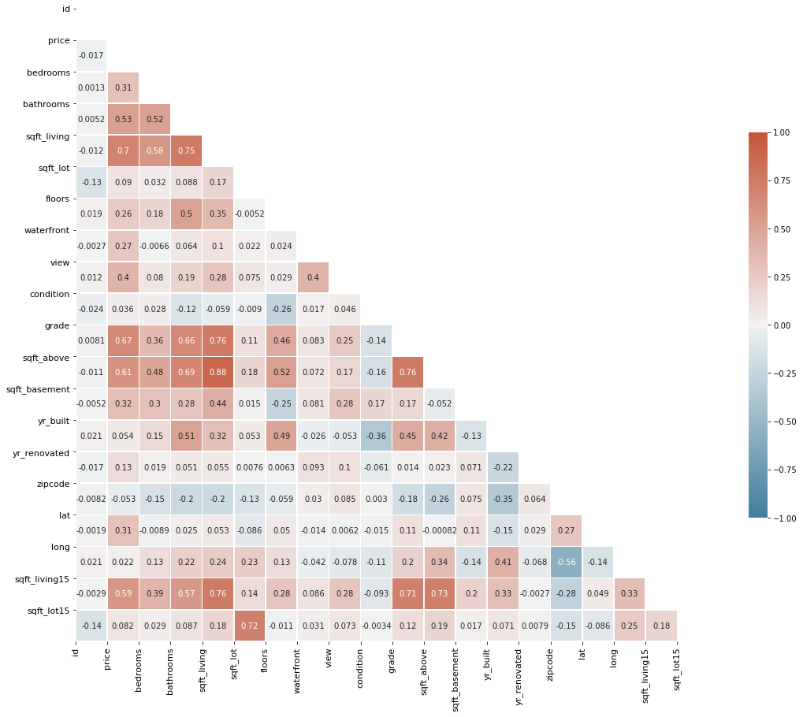

```python
# creating a correlation plot
plot_corr(df)
```

A correlation matrix is a table showing correlation coefficients between variables. Each cell in the table shows the correlation between two variables. This piece of information allows analysts to hypothesize under pairs of variables that are most likely to affect each other.

To have a better understanding on what these values mean:

- The correlation coefficient ranges from -1 to +1.
- The closer the coefficient gets to zero, the least the variables hold any kind of relationship.
- **Positive Correlation**: the coefficients are between 0 and 1. Under this case, as one variable increases, the other also increases.
- **Negative Correlation**: the coefficients are between -1 and 0. Under this case, as one variable increases, the other one decreases.

Yet, sometimes a **spurious correlation** may occur. When two random variables track each other closely on the matrix, it is easy to suspect correlation, or a relationship between the two factors, meaning that a change affects the other. However, many times these aligned movements are coincidental or caused by a third factor that affects the first two. This can be also called a confounding factor and scientists who analyze data must be on the lookout for spurious relationships all the time.

A practical example can be seen on the correlation results for the variables **price** and **sqft_living15**. It is very unlikely that the price of a house is so highly affected by the square footage of interior housing living of its nearest neighbors. Maybe this result is seen because the nearest houses have similar interior living square footage as the house we are analyzing, since they are located on a close or even on the same neighborhood. Still, it doesn't necessarily imply that the house we are interested in will always have a similar square footage as its neighbors. Thus, to say that a house price is directly correlated to its own living space square footage is more likely to be accurate than to imply that it is directly affected by its neighbors living spaces.

### 4. Exploratory Data Analysis

After understanding some of the data behavior, we have tools to answer the questions we have stated on the Business Problem section. We will start grouping houses by region to calculate the median price for that specific region, and then setting a condition for whether the company should buy a specific house or not. Then, the price variation due to seasonality will be analyzed to update the previous analysis.

#### Business Problem Nº1

When the house's price is below the median price of its region and has a condition index of 3 or higher, it is evaluated as a good deal and the company is advised to buy it. When the house's price is higher than the median price of its region and has a condition index of 3 or lower, it is evaluated as a risky deal and the company is advised to not buy it.

On the other hand, if the house's price is just a little bit higher than the median price of its region and both its condition and grade indexes are well rated, than the deal is put on hold for now. The final decision for these cases will be make on the next steps, after verifying some hypothesis and also the seasonality interference in sale prices.

```python
# filters the data of interest into a new dataframe
df_region = df.copy()
df_region.drop(columns=['bedrooms', 'bathrooms', 'sqft_living', 'floors',
                       'waterfront', 'view', 'sqft_above', 'sqft_basement',
                       'yr_built', 'yr_renovated', 'lat', 'long', 'sqft_lot15',
                       'sqft_living15', 'sqft_lot', 'date'],
               axis=1, inplace=True)

# calculates the median prices by region into a new dataframe
zip_median = df_region.groupby(['zipcode']).median().drop(columns=['id',
                                                                   'condition',
                                                                   'grade'])
zip_median = zip_median.rename(columns={'price': 'zip_median'})

zip_median
```

| zipcode | zip_median |
| --- | --- |
| 98001 | 260000.0 |
| 98002 | 235000.0 |
| 98003 | 267475.0 |
| 98004 | 1150000.0 |
| 98005 | 765475.0 |
| ... | ... |
| 98177 | 554000.0 |
| 98178 | 278277.0 |
| 98188 | 264000.0 |
| 98198 | 265000.0 |
| 98199 | 689800.0 |

70 rows × 1 columns

```python
# merges dataframes
df_median_region = pd.merge(df_region, zip_median, on='zipcode',
                            how='inner', sort=True)

df_median_region.set_index('zipcode', inplace=True, append=True, drop=True)
df_median_region.columns.names = ['attributes']

# iterates over the merged dataframe and displays houses status
for i in df_median_region.index.values:
    if df_median_region.loc[i, 'price'] < df_median_region.loc[i, 'zip_median'] and df_median_region.loc[i, 'condition'] >= 3 and df_median_region.loc[i, 'grade'] >= 5:
        df_median_region.loc[i, 'status'] = 'Buy'

    elif df_median_region.loc[i, 'price'] <= df_median_region.loc[i, 'zip_median']*1.05 and df_median_region.loc[i, 'condition'] >= 3 and df_median_region.loc[i, 'grade'] >= 9:
            df_median_region.loc[i, 'status'] = 'On Hold'

    else:
        df_median_region.loc[i, 'status'] = 'Not to buy'

# prints final table
df_median_region
```

|  | attributes zipcode | id | price | condition | grade | zip_median | status |
| --- | --- | --- | --- | --- | --- | --- | --- |
| 0 | 98001 | 7895500070 | 240000.0 | 2 | 7 | 260000.0 | Not to buy |
| 1 | 98001 | 3717000160 | 287000.0 | 3 | 7 | 260000.0 | Not to buy |
| 2 | 98001 | 8961960160 | 480000.0 | 3 | 9 | 260000.0 | Not to buy |
| 3 | 98001 | 4014400292 | 465000.0 | 3 | 9 | 260000.0 | Not to buy |
| 4 | 98001 | 1115450240 | 360000.0 | 3 | 9 | 260000.0 | Not to buy |
| ... | ... | ... | ... | ... | ... | ... | ... |
| 21608 | 98199 | 2770601912 | 570000.0 | 3 | 9 | 689800.0 | Buy |
| 21609 | 98199 | 1070000180 | 1107460.0 | 3 | 9 | 689800.0 | Not to buy |
| 21610 | 98199 | 7010700308 | 1010800.0 | 3 | 9 | 689800.0 | Not to buy |
| 21611 | 98199 | 2770601782 | 453000.0 | 3 | 8 | 689800.0 | Buy |
| 21612 | 98199 | 6821101731 | 549000.0 | 3 | 8 | 689800.0 | Buy |

21613 rows × 6 columns

```python
# checks status totals
stts_buy = df_median_region[df_median_region.status == 'Buy']
stts_not_buy = df_median_region[df_median_region.status == 'Not to buy']
stts_hold = df_median_region[df_median_region.status == 'On Hold']

print('Buying:               %d' %stts_buy.status.count(),
      '\nNot buying:           %d' %stts_not_buy.status.count(),
      '\nHolding Analysis:       %d' %stts_hold.status.count(),
      '\n===========================',
      '\nTotal houses:         %d' %(stts_buy.status.count() +
                                     stts_not_buy.status.count() +
                                     stts_hold.status.count()))
```

```
Buying:               10554
Not buying:           10899
Holding Analysis:       160
===========================
Total houses:         21613
```

If we were to conclude our analysis here, Greener Houses would have 10554 houses analyzed as good deals to buy, 10899 houses as businesses to avoid, and another 160 houses still in need of some more analysis prior decision making. However, there are still some important information to take into consideration, such as seasonality, that we'll consider on the next few topics, and that might change some of the results presented so far.

#### Business Problem Nº2

Now we need to understand how seasonality might affect houses pricing. Grouping houses by region and by seasonality (Summer, Spring, Fall and Winter), and then calculating the median price for each specific set of conditions will give us a broader view of price variation. Thus, it might interfere with the decision making process.

```python
# filters the data of interest into a new dataframe
df_season = df.copy()
df_season.drop(columns=['bedrooms', 'bathrooms', 'sqft_living', 'floors',
                       'waterfront', 'view', 'sqft_above', 'sqft_basement',
                       'yr_built', 'yr_renovated', 'lat', 'long', 'sqft_lot15',
                       'sqft_living15', 'sqft_lot'],
               axis=1, inplace=True)

# creates a dataset for days and months
seasn_day = pd.DatetimeIndex(df_season['date']).day
seasn_month = pd.DatetimeIndex(df_season['date']).month
seasn = pd.DataFrame(data={'day': seasn_day, 'month': seasn_month})

df_season
```

|  | id | date | price | condition | grade | zipcode |
| --- | --- | --- | --- | --- | --- | --- |
| 0 | 7129300520 | 20141013T000000 | 221900.0 | 3 | 7 | 98178 |
| 1 | 6414100192 | 20141209T000000 | 538000.0 | 3 | 7 | 98125 |
| 2 | 5631500400 | 20150225T000000 | 180000.0 | 3 | 6 | 98028 |
| 3 | 2487200875 | 20141209T000000 | 604000.0 | 5 | 7 | 98136 |
| 4 | 1954400510 | 20150218T000000 | 510000.0 | 3 | 8 | 98074 |
| ... | ... | ... | ... | ... | ... | ... |
| 21608 | 263000018 | 20140521T000000 | 360000.0 | 3 | 8 | 98103 |
| 21609 | 6600060120 | 20150223T000000 | 400000.0 | 3 | 8 | 98146 |
| 21610 | 1523300141 | 20140623T000000 | 402101.0 | 3 | 7 | 98144 |
| 21611 | 291310100 | 20150116T000000 | 400000.0 | 3 | 8 | 98027 |
| 21612 | 1523300157 | 20141015T000000 | 325000.0 | 3 | 7 | 98144 |

21613 rows × 6 columns

```python
# creates a column to classify dates into seasons
for i in range(len(seasn)):
    if seasn.loc[i, 'month'] in range(1,3):
        seasn.loc[i, 'season'] = 'Winter'

    elif seasn.loc[i, 'month'] == 3:
        if seasn.loc[i, 'day'] in range(1, 21):
            seasn.loc[i, 'season'] = 'Winter'
        else:
            seasn.loc[i, 'season'] = 'Spring'

    elif seasn.loc[i, 'month'] in range(4, 6):
        seasn.loc[i, 'season'] = 'Spring'

    elif seasn.loc[i, 'month'] == 6:
        if seasn.loc[i, 'day'] in range(1, 21):
            seasn.loc[i, 'season'] = 'Spring'
        else:
            seasn.loc[i, 'season'] = 'Summer'

    elif seasn.loc[i, 'month'] in range(7, 9):
        seasn.loc[i, 'season'] = 'Summer'

    elif seasn.loc[i, 'month'] == 9:
        if seasn.loc[i, 'day'] in range(1, 22):
            seasn.loc[i, 'season'] = 'Summer'
        else:
            seasn.loc[i, 'season'] = 'Fall'

    elif seasn.loc[i, 'month'] in range(10, 12):
        seasn.loc[i, 'season'] = 'Fall'

    elif seasn.loc[i, 'month'] == 12:
        if seasn.loc[i, 'day'] in range(1, 21):
            seasn.loc[i, 'season'] = 'Fall'
        else:
            seasn.loc[i, 'season'] = 'Winter'

seasn
```

|  | day | month | season |
| --- | --- | --- | --- |
| 0 | 13 | 10 | Fall |
| 1 | 9 | 12 | Fall |
| 2 | 25 | 2 | Winter |
| 3 | 9 | 12 | Fall |
| 4 | 18 | 2 | Winter |
| ... | ... | ... | ... |
| 21608 | 21 | 5 | Spring |
| 21609 | 23 | 2 | Winter |
| 21610 | 23 | 6 | Summer |
| 21611 | 16 | 1 | Winter |
| 21612 | 15 | 10 | Fall |

21613 rows × 3 columns

```python
# turns column "date" into "season"
df_season['date'] = seasn.season
df_season = df_season.rename(columns={'date': 'season'})

df_season
```

|  | id | season | price | condition | grade | zipcode |
| --- | --- | --- | --- | --- | --- | --- |
| 0 | 7129300520 | Fall | 221900.0 | 3 | 7 | 98178 |
| 1 | 6414100192 | Fall | 538000.0 | 3 | 7 | 98125 |
| 2 | 5631500400 | Winter | 180000.0 | 3 | 6 | 98028 |
| 3 | 2487200875 | Fall | 604000.0 | 5 | 7 | 98136 |
| 4 | 1954400510 | Winter | 510000.0 | 3 | 8 | 98074 |
| ... | ... | ... | ... | ... | ... | ... |
| 21608 | 263000018 | Spring | 360000.0 | 3 | 8 | 98103 |
| 21609 | 6600060120 | Winter | 400000.0 | 3 | 8 | 98146 |
| 21610 | 1523300141 | Summer | 402101.0 | 3 | 7 | 98144 |
| 21611 | 291310100 | Winter | 400000.0 | 3 | 8 | 98027 |
| 21612 | 1523300157 | Fall | 325000.0 | 3 | 7 | 98144 |

21613 rows × 6 columns

```python
#pd.set_option('display.max_rows', None)

# calculates median for each season and zipcode
seasn_median = df_season.groupby(['zipcode',
                                  'season']).median().drop(columns=['id',
                                                                    'condition',
                                                                    'grade'])
seasn_median = seasn_median.rename(columns={'price': 'seasn_median'})

# counts total house sample
houses_totals = df_season.groupby(['zipcode',
                                   'season']).count().drop(columns=['price',
                                                                    'condition',
                                                                    'grade'])
houses_totals = houses_totals.rename(columns={'id': 'house_totals'})

# merges median and count into a unique dataframe
df_median_seasn = pd.merge(seasn_median, houses_totals,
                           on=['zipcode', 'season'],
                            how='inner')

df_median_seasn
```

| zipcode | season | seasn_median | house_totals |
| --- | --- | --- | --- |
| 98001 | Fall | 250000.0 | 89 |
|  | Spring | 261000.0 | 106 |
|  | Summer | 263200.0 | 98 |
|  | Winter | 269950.0 | 69 |
| 98002 | Fall | 238000.0 | 49 |
| ... | ... | ... | ... |
| 98198 | Winter | 275000.0 | 63 |
| 98199 | Fall | 650000.0 | 81 |
|  | Spring | 730000.0 | 103 |
|  | Summer | 722500.0 | 82 |
|  | Winter | 604000.0 | 51 |

280 rows × 2 columns

```python
# filters season with max median for each zipcode
seasn_max = seasn_median.groupby(['zipcode']).max()

seasn_max = pd.merge(seasn_max, df_median_seasn.reset_index(),
                           on=['zipcode', 'seasn_median'],
                            how='inner').drop(columns=['house_totals'])

# grouping seasn_max by zipcode to avoid duplicated data (zipcodes with two equal seasons max medians)
seasn_max =seasn_max.groupby(['zipcode']).first().reset_index()

seasn_max = seasn_max.rename(columns={'seasn_median': 'max_median_seasn'})

seasn_max
```

|  | zipcode | max_median_seasn | season |
| --- | --- | --- | --- |
| 0 | 98001 | 269950.0 | Winter |
| 1 | 98002 | 238000.0 | Fall |
| 2 | 98003 | 280000.0 | Spring |
| 3 | 98004 | 1374000.0 | Winter |
| 4 | 98005 | 795000.0 | Spring |
| ... | ... | ... | ... |
| 65 | 98177 | 615000.0 | Spring |
| 66 | 98178 | 284000.0 | Fall |
| 67 | 98188 | 270000.0 | Summer |
| 68 | 98198 | 275000.0 | Winter |
| 69 | 98199 | 730000.0 | Spring |

70 rows × 3 columns

```python
# merges dataframes
df_seasn_zip = pd.merge(df_season, df_median_seasn,
                        on=['zipcode', 'season'],
                        how='left', sort=True)

df_seasn_zip = pd.merge(df_seasn_zip, seasn_max,
                        on=['zipcode'],
                        how='inner', suffixes=('','_of_max_median'))

# reorders columns
df_seasn_zip = pd.DataFrame(data=[df_seasn_zip['zipcode'], df_seasn_zip['id'],
                           df_seasn_zip['house_totals'], df_seasn_zip['season'],
                           df_seasn_zip['seasn_median'], df_seasn_zip['price'],
                           df_seasn_zip['season_of_max_median'],
                           df_seasn_zip['max_median_seasn'],
                           df_seasn_zip['condition'], df_seasn_zip['grade']]).T

# sets up dataframe
df_seasn_zip.set_index('zipcode', inplace=True, append=True, drop=True)
df_seasn_zip.columns.names = ['attributes']

df_seasn_zip
```

|  | attributes zipcode | id | house_totals | season | seasn_median | price | season_of_max_median | max_median_seasn | condition | grade |
| --- | --- | --- | --- | --- | --- | --- | --- | --- | --- | --- |
| 0 | 98001 | 3717000160 | 89 | Fall | 250000.0 | 287000.0 | Winter | 269950.0 | 3 | 7 |
| 1 | 98001 | 8961960160 | 89 | Fall | 250000.0 | 480000.0 | Winter | 269950.0 | 3 | 9 |
| 2 | 98001 | 1115450240 | 89 | Fall | 250000.0 | 360000.0 | Winter | 269950.0 | 3 | 9 |
| 3 | 98001 | 3353401710 | 89 | Fall | 250000.0 | 227950.0 | Winter | 269950.0 | 5 | 7 |
| 4 | 98001 | 8159610060 | 89 | Fall | 250000.0 | 233000.0 | Winter | 269950.0 | 3 | 7 |
| ... | ... | ... | ... | ... | ... | ... | ... | ... | ... | ... |
| 21608 | 98199 | 6933600456 | 51 | Winter | 604000.0 | 970000.0 | Spring | 730000.0 | 3 | 9 |
| 21609 | 98199 | 2351800065 | 51 | Winter | 604000.0 | 590000.0 | Spring | 730000.0 | 3 | 8 |
| 21610 | 98199 | 8127700845 | 51 | Winter | 604000.0 | 375000.0 | Spring | 730000.0 | 3 | 5 |
| 21611 | 98199 | 6821101732 | 51 | Winter | 604000.0 | 550000.0 | Spring | 730000.0 | 3 | 8 |
| 21612 | 98199 | 2770601457 | 51 | Winter | 604000.0 | 542300.0 | Spring | 730000.0 | 3 | 9 |

21613 rows × 9 columns

With data properly organized and some meaningful statistic parameters calculated, the houses will get an updated status considering new set of conditions to buy or not to buy a house.

Differently from the previous set of considerations, here we also consider as good deals houses with prices higher than the median for its own season, but lower than the max median among all seasons calculated over the same zipcode. This is because the company can make a good negotiation if it sells houses in a season when prices rise. Moreover, houses priced 60% or less of its season's median and that shape a good condition, holding a grade of at least 4, are considered as houses to renovate.

Finally, if the house is either overpriced or depreciated, it will be receive a not to buy label. The houses we put on hold on the previous section might have its status updated into "buy to renovate" or "not to buy", considering these new conditions.

```python
# iterates over the merged dataframe and displays houses status
for i in df_seasn_zip.index.values:
    if df_seasn_zip.loc[i, 'condition'] >= 3 and df_seasn_zip.loc[i, 'grade'] >= 5:

        if df_seasn_zip.loc[i, 'price'] < df_seasn_zip.loc[i, 'seasn_median']:
            df_seasn_zip.loc[i, 'status'] = 'Buy'

        elif df_seasn_zip.loc[i, 'price'] >= df_seasn_zip.loc[i, 'seasn_median'] and df_seasn_zip.loc[i, 'price'] < df_seasn_zip.loc[i, 'max_median_seasn']:
            df_seasn_zip.loc[i, 'status'] = 'Buy'

        elif df_seasn_zip.loc[i, 'price'] >= df_seasn_zip.loc[i, 'max_median_seasn']:
            df_seasn_zip.loc[i, 'status'] = 'Not to buy'

    elif df_seasn_zip.loc[i, 'price'] <= df_seasn_zip.loc[i, 'seasn_median']*0.60 and df_seasn_zip.loc[i, 'condition'] >= 3 and df_seasn_zip.loc[i, 'grade'] >= 4:
            df_seasn_zip.loc[i, 'status'] = 'Buy to renovate'

    else:
        df_seasn_zip.loc[i, 'status'] = 'Not to buy'

# prints final table
df_seasn_zip
```

|  | attributes zipcode | id | house_totals | season | seasn_median | price | season_of_max_median | max_median_seasn | condition | grade | status |
| --- | --- | --- | --- | --- | --- | --- | --- | --- | --- | --- | --- |
| 0 | 98001 | 3717000160 | 89 | Fall | 250000.0 | 287000.0 | Winter | 269950.0 | 3 | 7 | Not to buy |
| 1 | 98001 | 8961960160 | 89 | Fall | 250000.0 | 480000.0 | Winter | 269950.0 | 3 | 9 | Not to buy |
| 2 | 98001 | 1115450240 | 89 | Fall | 250000.0 | 360000.0 | Winter | 269950.0 | 3 | 9 | Not to buy |
| 3 | 98001 | 3353401710 | 89 | Fall | 250000.0 | 227950.0 | Winter | 269950.0 | 5 | 7 | Buy |
| 4 | 98001 | 8159610060 | 89 | Fall | 250000.0 | 233000.0 | Winter | 269950.0 | 3 | 7 | Buy |
| ... | ... | ... | ... | ... | ... | ... | ... | ... | ... | ... | ... |
| 21608 | 98199 | 6933600456 | 51 | Winter | 604000.0 | 970000.0 | Spring | 730000.0 | 3 | 9 | Not to buy |
| 21609 | 98199 | 2351800065 | 51 | Winter | 604000.0 | 590000.0 | Spring | 730000.0 | 3 | 8 | Buy |
| 21610 | 98199 | 8127700845 | 51 | Winter | 604000.0 | 375000.0 | Spring | 730000.0 | 3 | 5 | Buy |
| 21611 | 98199 | 6821101732 | 51 | Winter | 604000.0 | 550000.0 | Spring | 730000.0 | 3 | 8 | Buy |
| 21612 | 98199 | 2770601457 | 51 | Winter | 604000.0 | 542300.0 | Spring | 730000.0 | 3 | 9 | Buy |

21613 rows × 10 columns

To see the impact of these changes, we can print a new summary counting the labels and compare it with the one we generated before.

```python
# checks status totals
stts_buy_seasn = df_seasn_zip[df_seasn_zip.status == 'Buy']
stts_not_buy_seasn = df_seasn_zip[df_seasn_zip.status == 'Not to buy']
stts_renovate_seasn = df_seasn_zip[df_seasn_zip.status == 'Buy to renovate']

print('Buying:               %d' %stts_buy_seasn.status.count(),
      '\nNot buying:            %d' %stts_not_buy_seasn.status.count(),
      '\nBuying to renovate:      %d' %stts_renovate_seasn.status.count(),
      '\n===========================',
      '\nTotal houses:         %d' %(stts_buy_seasn.status.count() +
                                     stts_not_buy_seasn.status.count() +
                                     stts_renovate_seasn.status.count()))
```

```
Buying:               11840
Not buying:            9759
Buying to renovate:      14
===========================
Total houses:         21613
```

After setting up the new considerations, 1286 more houses now hold a "Buy" label and only 14 houses are up to be renovated. This is a significant changing on the business, since the company has now many other good deals available if some actions are taken.

Knowing this, it is now possible to indicate Greener Houses when to sell the houses and at what prices. The following table will only display houses over a "Buy" status.

```python
houses_to_buy = df_seasn_zip.query("status == 'Buy'")

for i in houses_to_buy.index.values:
    if houses_to_buy.loc[i, 'price'] < houses_to_buy.loc[i, 'seasn_median']*0.85:
        houses_to_buy.loc[i, 'sell_season'] = houses_to_buy.loc[i, 'season']
        houses_to_buy.loc[i, 'sell_price'] = houses_to_buy.loc[i, 'price']*1.30
        houses_to_buy.loc[i, 'profit'] = houses_to_buy.loc[i, 'sell_price'] - houses_to_buy.loc[i, 'price']

    elif houses_to_buy.loc[i, 'price'] >= houses_to_buy.loc[i, 'seasn_median']*0.85 and houses_to_buy.loc[i, 'price'] <= houses_to_buy.loc[i, 'seasn_median']*1.05:
        houses_to_buy.loc[i, 'sell_season'] = houses_to_buy.loc[i, 'season']
        houses_to_buy.loc[i, 'sell_price'] = houses_to_buy.loc[i, 'price']*1.15
        houses_to_buy.loc[i, 'profit'] = houses_to_buy.loc[i, 'sell_price'] - houses_to_buy.loc[i, 'price']

    elif houses_to_buy.loc[i, 'price'] > houses_to_buy.loc[i, 'seasn_median']*1.05 and houses_to_buy.loc[i, 'price'] < houses_to_buy.loc[i, 'max_median_seasn']*0.85:
        houses_to_buy.loc[i, 'sell_season'] = houses_to_buy.loc[i, 'season_of_max_median']
        houses_to_buy.loc[i, 'sell_price'] = houses_to_buy.loc[i, 'price']*1.30
        houses_to_buy.loc[i, 'profit'] = houses_to_buy.loc[i, 'sell_price'] - houses_to_buy.loc[i, 'price']

    elif houses_to_buy.loc[i, 'price'] >= houses_to_buy.loc[i, 'max_median_seasn']*0.85:
        houses_to_buy.loc[i, 'sell_season'] = houses_to_buy.loc[i, 'season_of_max_median']
        houses_to_buy.loc[i, 'sell_price'] = houses_to_buy.loc[i, 'price']*1.15
        houses_to_buy.loc[i, 'profit'] = houses_to_buy.loc[i, 'sell_price'] - houses_to_buy.loc[i, 'price']

houses_to_buy = houses_to_buy.drop(columns=['house_totals', 'seasn_median',
                                            'season_of_max_median', 'grade',
                                            'max_median_seasn', 'condition',
                                            'status'])

houses_to_buy
```

|  | attributes zipcode | id | season | price | sell_season | sell_price | profit |
| --- | --- | --- | --- | --- | --- | --- | --- |
| 3 | 98001 | 3353401710 | Fall | 227950.0 | Fall | 262142.5 | 34192.5 |
| 4 | 98001 | 8159610060 | Fall | 233000.0 | Fall | 267950.0 | 34950.0 |
| 5 | 98001 | 5066400483 | Fall | 249900.0 | Fall | 287385.0 | 37485.0 |
| 12 | 98001 | 3356404330 | Fall | 206000.0 | Fall | 267800.0 | 61800.0 |
| 13 | 98001 | 3874000240 | Fall | 210000.0 | Fall | 273000.0 | 63000.0 |
| ... | ... | ... | ... | ... | ... | ... | ... |
| 21607 | 98199 | 6917700305 | Winter | 529000.0 | Winter | 608350.0 | 79350.0 |
| 21609 | 98199 | 2351800065 | Winter | 590000.0 | Winter | 678500.0 | 88500.0 |
| 21610 | 98199 | 8127700845 | Winter | 375000.0 | Winter | 487500.0 | 112500.0 |
| 21611 | 98199 | 6821101732 | Winter | 550000.0 | Winter | 632500.0 | 82500.0 |
| 21612 | 98199 | 2770601457 | Winter | 542300.0 | Winter | 623645.0 | 81345.0 |

11840 rows × 6 columns

The next table will display houses holding a "Buy to renovate" status. At this point, we'll take some other issues in consideration.

The first considerations is that houses will have up to 40% their own prices available to spend in renovation so their condition ratings increase. Both second and third conditions relate to the profits. If a house's price is 50% or less the median price for the season, its selling price will be calculated as 60% more the house's price after the investments on renovation. On the other hand, if the house's price is more than 50% the median price for the season, its selling price will be 40% more the house's price after the outlay on renovation.

```python
houses_to_renovate = df_seasn_zip.query("status == 'Buy to renovate'")

for i in houses_to_renovate.index.values:
    if houses_to_renovate.loc[i, 'price'] <= houses_to_renovate.loc[i, 'seasn_median']*0.50:
        houses_to_renovate.loc[i, 'max_renovation_outlay'] = houses_to_renovate.loc[i, 'price']*0.40
        houses_to_renovate.loc[i, 'sell_season'] = houses_to_renovate.loc[i, 'season_of_max_median']
        houses_to_renovate.loc[i, 'sell_price'] = houses_to_renovate.loc[i, 'price']*1.40*1.60
        houses_to_renovate.loc[i, 'min_profit'] = houses_to_renovate.loc[i, 'sell_price'] - houses_to_renovate.loc[i, 'price']

    elif houses_to_renovate.loc[i, 'price'] > houses_to_renovate.loc[i, 'seasn_median']*0.50:
        houses_to_renovate.loc[i, 'max_renovation_outlay'] = houses_to_renovate.loc[i, 'price']*0.40
        houses_to_renovate.loc[i, 'sell_season'] = houses_to_renovate.loc[i, 'season_of_max_median']
        houses_to_renovate.loc[i, 'sell_price'] = houses_to_renovate.loc[i, 'price']*1.40*1.40
        houses_to_renovate.loc[i, 'min_profit'] = houses_to_renovate.loc[i, 'sell_price'] - houses_to_renovate.loc[i, 'max_renovation_outlay'] - houses_to_renovate.loc[i, 'price']

houses_to_renovate = houses_to_renovate.drop(columns=['house_totals', 'seasn_median',
                                                      'season_of_max_median', 'max_median_seasn',
                                                      'condition', 'grade', 'status'])

houses_to_renovate
```

|  | attributes zipcode | id | season | price | max_renovation_outlay | sell_season | sell_price | min_profit |
| --- | --- | --- | --- | --- | --- | --- | --- | --- |
| 2661 | 98014 | 8655900162 | Winter | 156000.0 | 62400.0 | Summer | 349440.0 | 193440.0 |
| 3601 | 98024 | 6730700385 | Fall | 205000.0 | 82000.0 | Spring | 459200.0 | 254200.0 |
| 3763 | 98027 | 5279100625 | Spring | 248000.0 | 99200.0 | Summer | 555520.0 | 307520.0 |
| 4046 | 98027 | 2354300456 | Winter | 130000.0 | 52000.0 | Summer | 291200.0 | 161200.0 |
| 5145 | 98031 | 1822059057 | Summer | 152000.0 | 60800.0 | Fall | 297920.0 | 85120.0 |
| 5301 | 98032 | 6146600170 | Summer | 100000.0 | 40000.0 | Summer | 224000.0 | 124000.0 |
| 8990 | 98055 | 3340401535 | Fall | 140000.0 | 56000.0 | Spring | 313600.0 | 173600.0 |
| 10196 | 98059 | 3664500300 | Fall | 230000.0 | 92000.0 | Spring | 450800.0 | 128800.0 |
| 11303 | 98074 | 1925069006 | Fall | 355000.0 | 142000.0 | Spring | 695800.0 | 198800.0 |
| 13606 | 98106 | 6453300055 | Fall | 188000.0 | 75200.0 | Winter | 368480.0 | 105280.0 |
| 13728 | 98106 | 2114700500 | Spring | 90000.0 | 36000.0 | Winter | 201600.0 | 111600.0 |
| 13897 | 98106 | 2114700090 | Winter | 151000.0 | 60400.0 | Winter | 338240.0 | 187240.0 |
| 18556 | 98136 | 4322200105 | Spring | 229050.0 | 91620.0 | Winter | 513072.0 | 284022.0 |
| 21136 | 98198 | 6929602721 | Spring | 95000.0 | 38000.0 | Winter | 212800.0 | 117800.0 |

This analysis provides Greener Houses with a complete summary containing all the houses status, sales prices, sales seasons, profits, and outlays on renovation when required. Now the company can use these information to improve its decision-making process, and also to have a better understanding on its own businesses, incomes and outcomes on each particular deal.

However, to have an even better looking on the results of this analysis, we'll provide Greener Houses with a neat graphical data visualization, performed on the next section.

### 5. Communicating Results

#### Evaluating Hypothesis

Here we can see whether to support or reject a hypothesis. All hypothesis here are evaluated both by means of graphs and calculations.

##### H1: Overlooking the Waterfront

Testing if houses overlooking the waterfront are 30% more expensive, on average.

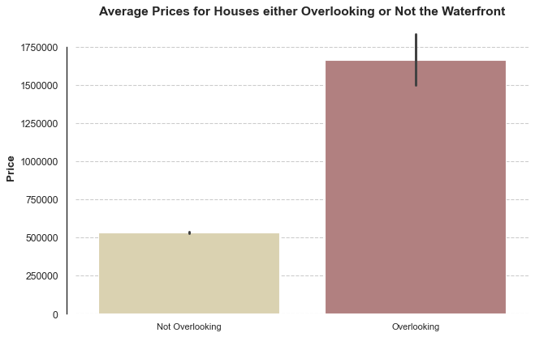

```python
# figure size
fig = plt.figure(figsize=(9,6), dpi=80)

# creating bars
ax = sns.barplot(data=df, x='waterfront', y='price',
                 palette='pink_r')

# setting up style
sns.set_theme(style='ticks')
sns.despine(top=True, bottom=True, trim=True, offset=10)
plt.grid(axis='y', linestyle='--')

# setting up axis and title
plt.title('Average Prices for Houses either Overlooking or Not the Waterfront', fontsize=14, fontweight='bold')
plt.xlabel('')
plt.ylabel('Price', fontsize=12, fontweight='bold')
ax.set_xticklabels(['Not Overlooking', 'Overlooking'])
plt.rcParams['xtick.labelsize'] = 10
plt.rcParams['ytick.labelsize'] = 10

# saving the plot
ax.get_yaxis().get_major_formatter().set_scientific(False)
plt.savefig("plots/average-prices-for-houses-either-overlooking-or-not-the-waterfront.png", dpi=300, bbox_inches='tight')
plt.show()
```

From a first look on the chart, it is possible to assume that this hypothesis will be reject even without confirming through calculations. However, to make it totally visible, the numbers below describe the accurate relationship between the two cases.

```python
# creates variables for both cases
wtfront = df.loc[df['waterfront'] == 1]
not_wtfront = df.loc[df['waterfront'] == 0]

prices_wtfront = wtfront['price']
prices_not_wtfront = not_wtfront['price']

# displays average prices for both cases
wtfront_mean = prices_wtfront.mean()
not_wtfront_mean = prices_not_wtfront.mean()

print('Average prices for houses:'
     '\n\nOverlooking waterfront      >> U$ %.2f' %wtfront_mean,
     '\nNOT overlooking waterfront  >> U$ %.2f' %not_wtfront_mean)

# calculates percentage
percent_wtfront = (abs(wtfront_mean-not_wtfront_mean)/not_wtfront_mean)*100

# displays comparison
print('\nResults:',
      '\n\nHouses overlooking the waterfront are %.2f%% more expensive' %percent_wtfront,
      '\nthan houses not overlooking the waterfront, on average.')
```

```
Average prices for houses:

Overlooking waterfront      >> U$ 1661876.02
NOT overlooking waterfront  >> U$ 531563.60

Results:

Houses overlooking the waterfront are 212.64% more expensive
than houses not overlooking the waterfront, on average.
```

**REJECTED**

##### H2: Built Prior to 1995

Testing if houses with a construction date prior to 1995 are 50% cheaper, on average.

```python
# creates variables
prior_1995 = df.loc[df['yr_built'] < 1995]
after_1995 = df.loc[df['yr_built'] >= 1995]

prices_prior_1995 = pd.DataFrame(prior_1995.price)
prices_after_1995 = pd.DataFrame(after_1995.price)

# points whether the house was built prior or after 1995
prices_prior_1995['prior_1995'] = 1
prices_after_1995['prior_1995'] = 0

# concat Dataframes into a unique
df_yr_built = pd.concat([prices_prior_1995, prices_after_1995], axis=0, join='outer')
columns = ['price', 'prior_1995']
df_yr_built.columns = columns
```

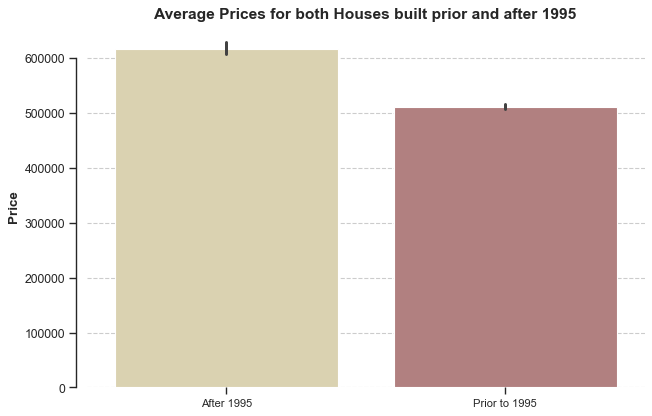

```python
# figure size
fig = plt.figure(figsize=(9,6), dpi=80)

# creating bars
ax = sns.barplot(data=df_yr_built, x='prior_1995', y='price',
                 palette='pink_r')

# setting up style
sns.set_theme(style='ticks')
sns.despine(top=True, bottom=True, trim=True, offset=10)
plt.grid(axis='y', linestyle='--')

# setting up axis and title
plt.title('Average Prices for both Houses built prior and after 1995', fontsize=14, fontweight='bold')
plt.xlabel('')
plt.ylabel('Price', fontsize=12, fontweight='bold')
ax.set_xticklabels(['After 1995', 'Prior to 1995'])
plt.rcParams['xtick.labelsize'] = 10
plt.rcParams['ytick.labelsize'] = 10

# saving the plot
ax.get_yaxis().get_major_formatter().set_scientific(False)
plt.savefig("plots/average-prices-for-both-houses-built-prior-and-after-1995.png", dpi=300, bbox_inches='tight')
plt.show(fig)
```

We can also see that the second bar represents more than 50% of the first one. It means that it is not possible that houses built prior to 1995 are 50% cheaper than houses built after 1995. However, the accurate relationship between the two cases are calculated below.

```python
# displays average prices for both cases
prior_1995_mean = prices_prior_1995.price.mean()
after_1995_mean = prices_after_1995.price.mean()

print('Average prices for houses:'
     '\n\nBuilt prior to 1995      >> U$ %.2f' %prior_1995_mean,
     '\nBuilt from 1995 onwards  >> U$ %.2f' %after_1995_mean)

# calculates percentage
percent_yr_built = (abs(prior_1995_mean-after_1995_mean)/after_1995_mean)*100

# displays comparison
print('\nResults:',
      '\n\nHouses built prior to 1995 are %.2f%% cheaper' %percent_yr_built,
      '\nthan houses built from 1995 onwards, on average.')
```

```
Average prices for houses:

Built prior to 1995      >> U$ 511660.72
Built from 1995 onwards  >> U$ 617519.07

Results:

Houses built prior to 1995 are 17.14% cheaper
than houses built from 1995 onwards, on average.
```

**REJECTED**

##### H3: Prices for 2 or 3 Bathrooms

Testing if houses with 2 bathrooms are 35% cheaper than houses with 3 bathrooms, on average.

```python
# creates variables
baths_2 = df[df['bathrooms'] == 2]
baths_3 = df[df['bathrooms'] == 3]

prices_baths_2 = pd.DataFrame(baths_2.price)
prices_baths_3 = pd.DataFrame(baths_3['price'])

# points whether the house has 2 or 3 bathroomns
prices_baths_2['num_bath'] = 2
prices_baths_3['num_bath'] = 3

# concat Dataframes into a unique
df_num_bath = pd.concat([prices_baths_2, prices_baths_3], axis=0, join='outer')
columns = ['price', 'num_bath']
df_num_bath.columns = columns
```

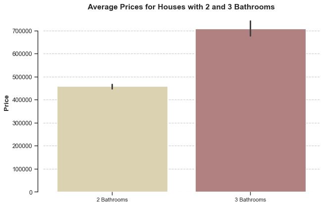

```python
# figure size
fig = plt.figure(figsize=(9,6), dpi=80)

# creating bars
ax = sns.barplot(data=df_num_bath, x='num_bath', y='price',
                 palette='pink_r')

# setting up style
sns.set_theme(style='ticks')
sns.despine(top=True, bottom=True, trim=True, offset=10)
plt.grid(axis='y', linestyle='--')

# creates variables
baths_2 = df[df['bathrooms'] == 2]
baths_3 = df[df['bathrooms'] == 3]

prices_baths_2 = pd.DataFrame(baths_2.price)
prices_baths_3 = pd.DataFrame(baths_3['price'])

# points whether the house has 2 or 3 bathroomns
prices_baths_2['num_bath'] = 2
prices_baths_3['num_bath'] = 3

# concat Dataframes into a unique
df_num_bath = pd.concat([prices_baths_2, prices_baths_3], axis=0, join='outer')
columns = ['price', 'num_bath']
df_num_bath.columns = columns

# setting up axis and title
plt.title('Average Prices for Houses with 2 and 3 Bathrooms', fontsize=14, fontweight='bold')
plt.xlabel('')
plt.ylabel('Price', fontsize=12, fontweight='bold')
ax.set_xticklabels(['2 Bathrooms', '3 Bathrooms'])
plt.rcParams['xtick.labelsize'] = 10
plt.rcParams['ytick.labelsize'] = 10

# saving the plot
ax.get_yaxis().get_major_formatter().set_scientific(False)
plt.savefig("plots/average-prices-for-houses-with-2-and-3-bathrooms.png", dpi=300, bbox_inches='tight')
plt.show(fig)
```

It's possible to confirm from the graph that houses with 3 bathrooms are more expensive than houses with 2 bathrooms on average. We can also see that the first bar represents more than 50% of the second one. It means that it is possible that houses with 2 bathrooms are close to 35% cheaper than houses with 3 bathrooms. However, to have the number calculating the accurate relationship between the two cases, the percentage is shown as below.

```python
# displays average prices for both cases
baths_2_mean = prices_baths_2.price.mean()
baths_3_mean = prices_baths_3.price.mean()

print('Average prices for houses:'
     '\n\nWith 02 bathrooms   >> U$ %.2f' %baths_2_mean,
     '\nWith 03 bathrooms   >> U$ %.2f' %baths_3_mean)

# calculates percentage
percent_n_baths = (abs(baths_2_mean-baths_3_mean)/baths_3_mean)*100

# displays comparison
print('\nResults:',
      '\n\nHouses with 02 bathrooms are %.2f%% cheaper' %percent_n_baths,
      '\nthan houses with 03 bathrooms, on average.')
```

```
Average prices for houses:

With 02 bathrooms   >> U$ 457889.72
With 03 bathrooms   >> U$ 708415.23

Results:

Houses with 02 bathrooms are 35.36% cheaper
than houses with 03 bathrooms, on average.
```

**SUPPORTED**

##### H4: Grades and Prices

Testing if houses with grades 9 or higher are 75% more expensive than houses with grades 7 or lower, on average.

```python
# creates variables
grade_9 = df[df['grade'] >= 9]
grade_7 = df[df['grade'] <= 7]

prices_grade_9 = pd.DataFrame(grade_9['price'])
prices_grade_7 = pd.DataFrame(grade_7.price)

# points whether the house is graded 9+ or 7-
prices_grade_9['grade_lim'] = 9
prices_grade_7['grade_lim'] = 7

# concat Dataframes into a unique
df_grade_lim = pd.concat([prices_grade_9, prices_grade_7], axis=0, join='outer')
columns = ['price', 'grade_lim']
df_grade_lim.columns = columns
```

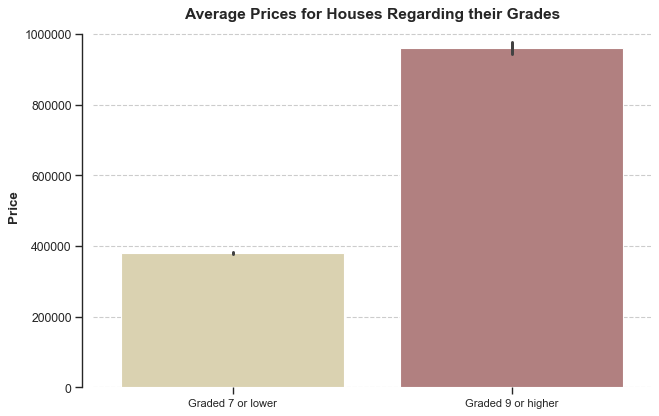

```python
# figure size
fig = plt.figure(figsize=(9,6), dpi=80)

# creating bars
ax = sns.barplot(data=df_grade_lim, x='grade_lim', y='price',
                 palette='pink_r')

# setting up style
sns.set_theme(style='ticks')
sns.despine(top=True, bottom=True, trim=True, offset=10)
plt.grid(axis='y', linestyle='--')

# setting up axis and title
plt.title('Average Prices for Houses Regarding their Grades', fontsize=14, fontweight='bold')
plt.xlabel('')
plt.ylabel('Price', fontsize=12, fontweight='bold')
ax.set_xticklabels(['Graded 7 or lower', 'Graded 9 or higher'])
plt.rcParams['xtick.labelsize'] = 10
plt.rcParams['ytick.labelsize'] = 10

# saving the plot
ax.get_yaxis().get_major_formatter().set_scientific(False)
plt.savefig("plots/average-prices-for-houses-regarding-their-grades.png", dpi=300, bbox_inches='tight')
plt.show(fig)
```

From the graph, it's noticeable that houses graded 9 or higher have more than twice the price of houses graded 7 or less. It means that this hypothesis will probably be rejected. However, to have an accurate relationship, the numbers below calculate the average prices for the two cases, and the percentage as displayed.

```python
# displays average prices for both cases
grade_9_mean = prices_grade_9.price.mean()
grade_7_mean = prices_grade_7.price.mean()

print('Average prices for houses:'
     '\n\nWith grades 9 or higher   >> U$ %.2f' %grade_9_mean,
     '\nWith grades 7 or lower    >> U$ %.2f' %grade_7_mean)

# calculates percentage
percent_grade = (abs(grade_9_mean-grade_7_mean)/grade_7_mean)*100

# displays comparison
print('\nResults:',
      '\n\nHouses with grade 9 or higher are %.2f%% more expensive' %percent_grade,
      '\nthan houses with grades 7 or lower, on average.')
```

```
Average prices for houses:

With grades 9 or higher   >> U$ 959962.41
With grades 7 or lower    >> U$ 380564.39

Results:

Houses with grade 9 or higher are 152.25% more expensive
than houses with grades 7 or lower, on average.
```

**REJECTED**

##### H5: With or Without Basements

Testing if houses with basements have a total area (sqft lot) 40% larger than houses without basements.

```python
# creates new Dataframe
basement = df[df['sqft_basement'] != 0]
no_basement = df[df['sqft_basement'] == 0]

area_basement = pd.DataFrame(basement.sqft_lot)
area_no_basement = pd.DataFrame(no_basement.sqft_lot)

# points whether the house has basement or not
area_basement['bsmt'] = 1
area_no_basement['bsmt'] = 0

# concat Dataframes into a unique
df_basement = pd.concat([area_basement, area_no_basement], axis=0, join='outer')
columns = ['sqft_lot', 'bsmt']
df_basement.columns = columns
```

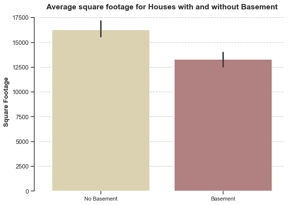

```python
# figure size
fig = plt.figure(figsize=(8,6), dpi=80)

# creating bars
ax = sns.barplot(data=df_basement, x='bsmt', y='sqft_lot',
                 palette='pink_r')

# setting up style
sns.set_theme(style='ticks')
sns.despine(top=True, bottom=True, trim=True, offset=10)
plt.grid(axis='y', linestyle='--')

# setting up axis and title
plt.title('Average square footage for Houses with and without Basement', fontsize=14, fontweight='bold')
plt.xlabel('')
plt.ylabel('Square Footage', fontsize=12, fontweight='bold')
ax.set_xticklabels(['No Basement', 'Basement'])
plt.rcParams['xtick.labelsize'] = 10
plt.rcParams['ytick.labelsize'] = 10

# saving the plot
ax.get_yaxis().get_major_formatter().set_scientific(False)
plt.savefig("plots/average-square-footage-for-houses-with-and-without-basement.png", dpi=300, bbox_inches='tight')
plt.show()
```

From a first look on the chart, it is possible to assume that this hypothesis will be reject. However, to make it clear, the numbers below describe the accurate relationship between the two cases.

```python
# displays average total area for both cases
basement_mean = area_basement.sqft_lot.mean()
no_basement_mean = area_no_basement.sqft_lot.mean()

print('Average total square footage for houses:'
     '\n\nWith basement      >> %.2f sqft.' %basement_mean,
     '\nWithout basement   >> %.2f sqft.' %no_basement_mean)

# calculates percentage
percent_basements = (abs(basement_mean-no_basement_mean)/no_basement_mean)*100

# displays comparison
print('\nResults:',
      '\n\nHouses with basements are %.2f%% smaller' %percent_basements,
      '\nthan houses without basements, on average.')
```

```
Average total square footage for houses:

With basement      >> 13286.29 sqft.
Without basement   >> 16284.18 sqft.

Results:

Houses with basements are 18.41% smaller
than houses without basements, on average.
```

**REJECTED**

##### H6: MoM positive Growth

Testing if houses with 3 bathrooms have a MoM (Month over Month) positive growth within time.

```python
# creates dataframe with dates and converts them to DateTime
date_df = pd.DataFrame(df.date)
date_df.date = pd.to_datetime(date_df['date'])

# creates a range of sorted dates starting on the earlier date of the dataset
interval = pd.date_range(start=date_df.min().item(), periods=360)

# creates a list for monthly intervals of 30 days
j = 30
days = [day for day in interval[:j]]

# iniciates variables
prev_monthly_avg = 0
monthly_avg_list = []
variation_list = []
total_houses = []

# iterates over df and calculates mean for prices on the date range each month
for period in range(12):
    monthly_prices = []

    for i in range(len(df)):
        if date_df.loc[i, 'date'] in days and df.loc[i, 'bathrooms'] == 3:
            monthly_prices.append(df.loc[i, 'price'])

    # calculates monthly average prices
    monthly_avg = sum(monthly_prices)/len(monthly_prices)
    monthly_avg_list.append(monthly_avg)
    total_houses.append(len(monthly_prices))

    if prev_monthly_avg > 0:
        # calculates variation
        variation = ((monthly_avg-prev_monthly_avg)/prev_monthly_avg)*100
        variation_list.append(variation)
    else:
        variation_list.append(0)

    prev_monthly_avg = monthly_avg
    days = [day for day in interval[j:j+30]]
    j += 30

# creates dataframe with records
MoM_variation = pd.DataFrame(data={'month': range(1, 13),
                                   'total_3_bathrooms': total_houses,
                                   'avg_prices': monthly_avg_list,
                                   'MoM_variation (%)': variation_list})

MoM_variation.set_index(['month'], inplace=True)

MoM_variation.round(3)
```

| month | total_3_bathrooms | avg_prices | MoM_variation (%) |
| --- | --- | --- | --- |
| 1 | 70 | 690080.714 | 0.000 |
| 2 | 78 | 775057.564 | 12.314 |
| 3 | 68 | 748064.015 | -3.483 |
| 4 | 66 | 730831.818 | -2.304 |
| 5 | 68 | 651971.015 | -10.791 |
| 6 | 60 | 643131.150 | -1.356 |
| 7 | 52 | 667909.615 | 3.853 |
| 8 | 42 | 721742.310 | 8.060 |
| 9 | 39 | 636911.538 | -11.754 |
| 10 | 49 | 741176.510 | 16.370 |
| 11 | 53 | 687297.075 | -7.269 |
| 12 | 77 | 764233.974 | 11.194 |

```python
MoM_variation.describe().round(2)
```

|  | total_3_bathrooms | avg_prices | MoM_variation (%) |
| --- | --- | --- | --- |
| count | 12.00 | 12.00 | 12.00 |
| mean | 60.17 | 704867.27 | 1.24 |
| std | 13.06 | 48349.95 | 9.21 |
| min | 39.00 | 636911.54 | -11.75 |
| 25% | 51.25 | 663924.97 | -4.43 |
| 50% | 63.00 | 705911.51 | -0.68 |
| 75% | 68.50 | 742898.39 | 8.84 |
| max | 78.00 | 775057.56 | 16.37 |

Houses with 3 bathrooms have a miscellaneous MoM (Month over Month) price variation. Thus, we are not able to state, form this set of data, that this variation will always grow positively within time. Additionally, to support the results, we can also see how the price behave over time on the graphic below.

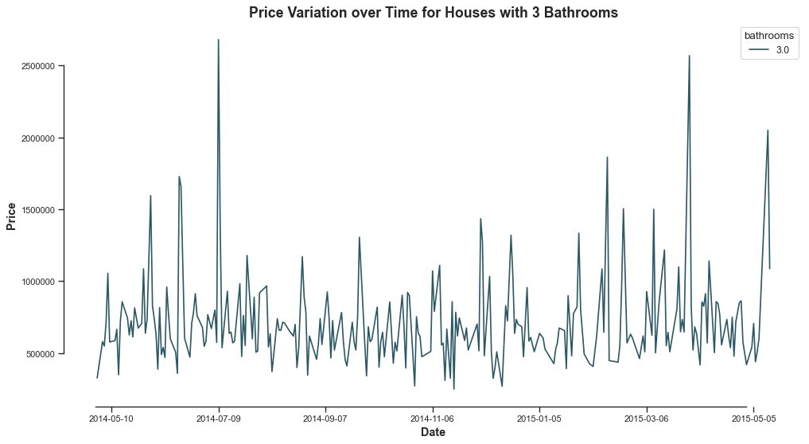

```python
# figure size
fig = plt.figure(figsize=(15,8), dpi=80)
df.date = pd.to_datetime(df['date'])

# creating lines
ax = sns.lineplot(data=df.query('bathrooms == 3'),
                  x='date', y='price', hue='bathrooms',
                  palette='ch:l=.3,r=-.5', ci=None)

# setting up style
sns.set_style('white')
sns.despine(top=True, trim=True)

# setting up axis and title
plt.title('Price Variation over Time for Houses with 3 Bathrooms', fontsize=16, fontweight='bold')
plt.xlabel('Date', fontsize=13, fontweight='bold')
plt.ylabel('Price', fontsize=13, fontweight='bold')
plt.rcParams['xtick.labelsize'] = 10
plt.rcParams['ytick.labelsize'] = 10
ax.get_yaxis().get_major_formatter().set_scientific(False)

# limiting number of values on each axis
ax.xaxis.set_major_locator(plt.MaxNLocator(7))
ax.yaxis.set_major_locator(plt.MaxNLocator(6))

# saving the plot
plt.savefig("plots/price-variation-over-time-for-houses-with-3-bathrooms.png", dpi=300, bbox_inches='tight')
plt.show()
```

**REJECTED**

#### Graphical Data Visualization

Under this section, the business problems answers are found in a graphical shape, communicating the tables results on the previous sections in a different and more readable format. Here are the graphics you might find:

- Prices Dispersion
- Prices Dispersion for Houses to Buy
- Median Prices by Zipcode
- Total Number of Houses to Buy
- Average Profit on Houses to Buy by region
- Total Sales by Season
- Houses to Renovate Summary

Prices Dispersion

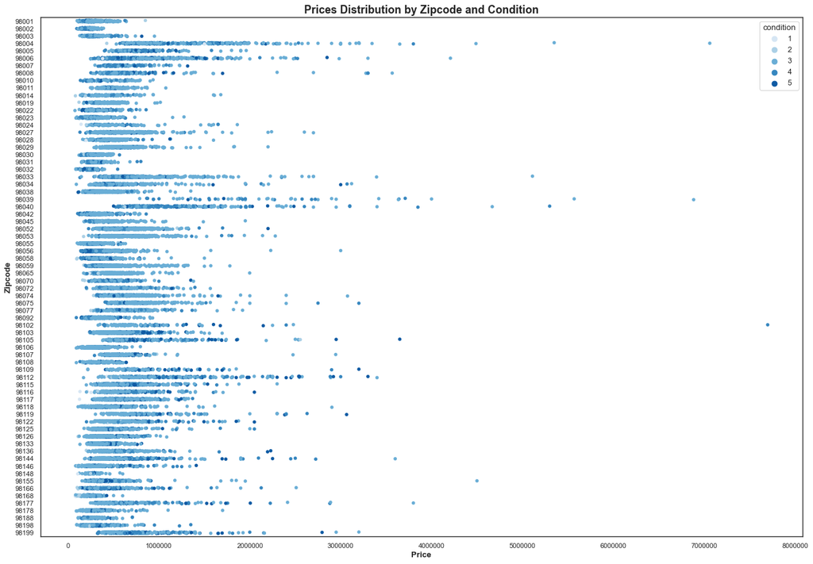

```python
# figure size
fig = plt.figure(figsize=(20,14), dpi=80)

# creating scatters
ax = sns.stripplot(data=df, x="price", y="zipcode",
                   hue="condition", orient="h",
                   palette="Blues")

# setting up style
sns.set_style('darkgrid')

# setting up axis and title
plt.title('Prices Distribution by Zipcode and Condition', fontsize=16, fontweight='bold')
plt.xlabel('Price', fontsize=12, fontweight='bold')
plt.ylabel('Zipcode', fontsize=12, fontweight='bold')
plt.rcParams['xtick.labelsize'] = 10
plt.rcParams['ytick.labelsize'] = 10
ax.get_xaxis().get_major_formatter().set_scientific(False)

# saving the plot
plt.savefig("plots/prices-distribution-by-zipcode-and-condition.png", dpi=300, bbox_inches='tight')
plt.show()
```

Prices Dispertion for Houses to Buy

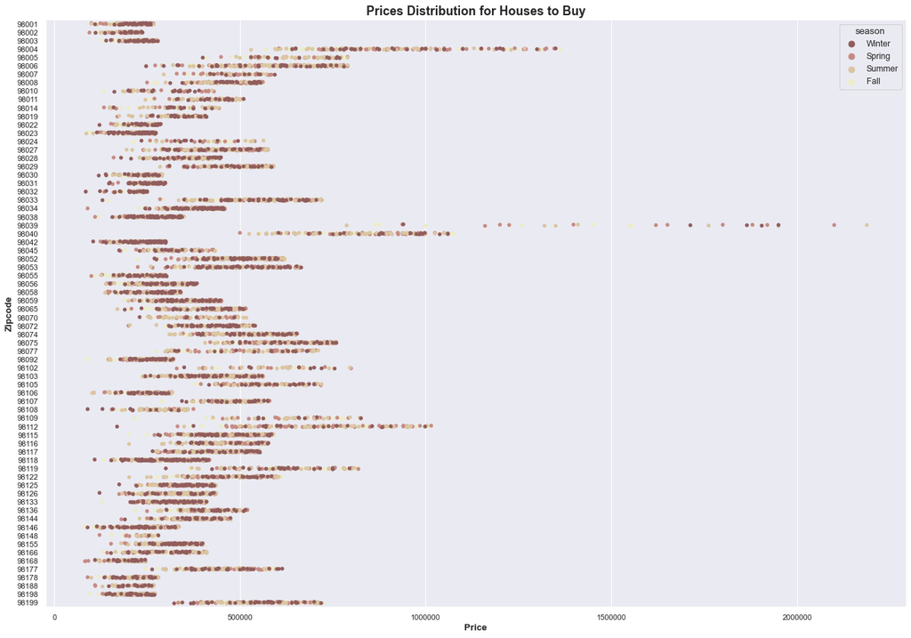

```python
# figure size
fig = plt.figure(figsize=(20,14), dpi=80)

# creating scatters
ax = sns.stripplot(data=houses_to_buy.reset_index(), x="price", y="zipcode",
                   hue="season", hue_order=['Winter', 'Spring','Summer',  'Fall'],
                   palette="pink", orient="h")

# setting up style
sns.set_style('darkgrid')

# setting up axis and title
plt.title('Prices Distribution for Houses to Buy', fontsize=16, fontweight='bold')
plt.xlabel('Price', fontsize=12, fontweight='bold')
plt.ylabel('Zipcode', fontsize=12, fontweight='bold')
plt.rcParams['xtick.labelsize'] = 10
plt.rcParams['ytick.labelsize'] = 10
ax.get_xaxis().get_major_formatter().set_scientific(False)

# saving the plot
plt.savefig("plots/prices-distribution-for-houses-to-buy.png", dpi=300, bbox_inches='tight')
plt.show()
```

Median Prices by Zipcode

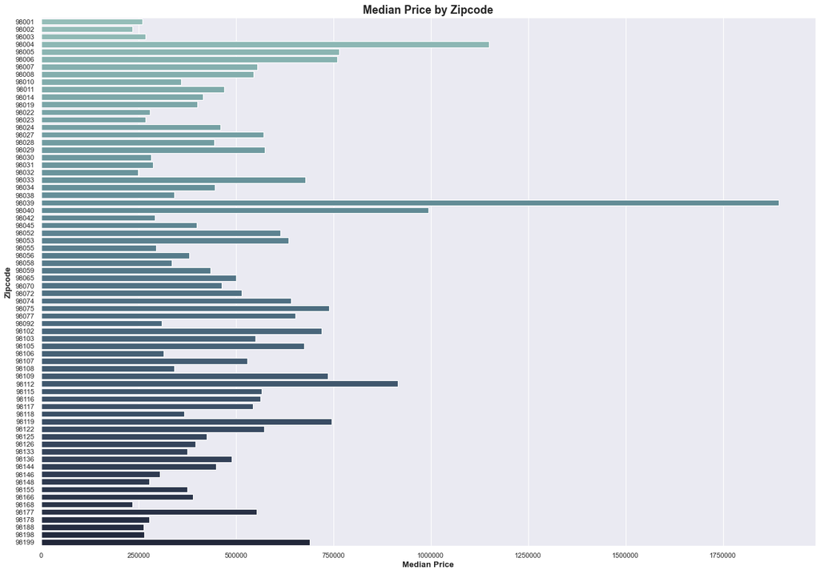

```python
# figure size
fig = plt.figure(figsize=(20,14), dpi=80)

# creating bars
ax = sns.barplot(data=df_season, y="zipcode", x="price",
                 estimator=np.median, orient="h", ci=None,
                 palette="ch:r=-.3,g=1,l=.7")

# setting up style
sns.set_theme(style='darkgrid')

# setting up axis and title
plt.title('Median Price by Zipcode', fontsize=16, fontweight='bold')
plt.xlabel('Median Price', fontsize=12, fontweight='bold')
plt.ylabel('Zipcode', fontsize=12, fontweight='bold')
plt.rcParams['xtick.labelsize'] = 10
plt.rcParams['ytick.labelsize'] = 10
ax.get_xaxis().get_major_formatter().set_scientific(False)

# saving the plot
plt.savefig("plots/median-price-by-zipcode.png", dpi=300, bbox_inches='tight')
plt.show()
```

Total Number of Houses to Buy

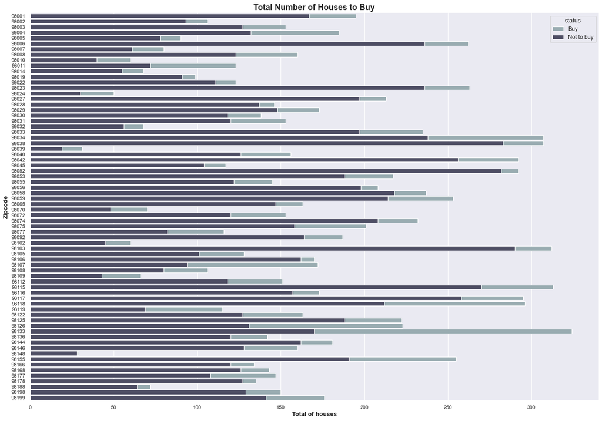

```python
# figure size
fig = plt.figure(figsize=(20,14), dpi=80)

# creating bars
ax = sns.countplot(data=df_seasn_zip.reset_index().query("status == 'Buy' or status == 'Not to buy'"),
                   y="zipcode", orient="h", dodge=False,
                   palette="bone_r", hue='status',
                   hue_order=['Buy', "Not to buy"])

# setting up style
sns.set_theme(style='whitegrid')
sns.despine(left=True, right=True, top=True, bottom=True)

# setting up axis and title
plt.title('Total Number of Houses to Buy', fontsize=16, fontweight='bold')
plt.xlabel('Total of houses', fontsize=12, fontweight='bold')
plt.ylabel('Zipcode', fontsize=12, fontweight='bold')
plt.rcParams['xtick.labelsize'] = 10
plt.rcParams['ytick.labelsize'] = 10

# saving the plot
plt.savefig("plots/total-number-of-houses-to-buy.png", dpi=300, bbox_inches='tight')
plt.show()
```

Average Profit on Houses to Buy by Region

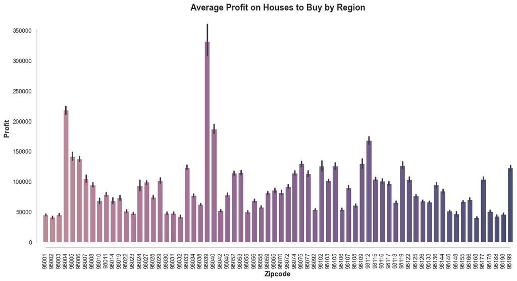

```python
# figure size
fig = plt.figure(figsize=(16,8), dpi=80)

# creating bars
sns.barplot(data=houses_to_buy.reset_index(), estimator=np.mean,
            x='zipcode', y='profit', palette='ch:s=2,l=.6,r=1,d=.3')

# setting up style
sns.set_theme(style='ticks')
sns.despine(top=True, offset=10, trim=True)
plt.grid(axis='y', linestyle='--')

# setting up axis and title
plt.title('Average Profit on Houses to Buy by Region', fontsize=16, fontweight='bold')
plt.xlabel('Zipcode', fontsize=13, fontweight='bold')
plt.ylabel('Profit', fontsize=13, fontweight='bold')
plt.rcParams['xtick.labelsize'] = 9
plt.rcParams['ytick.labelsize'] = 9
plt.xticks(rotation=90)

# saving the plot
plt.savefig("plots/average-profit-on-houses-to-buy-by-region.png", dpi=300, bbox_inches='tight')
plt.show()
```

Total Sales by Season

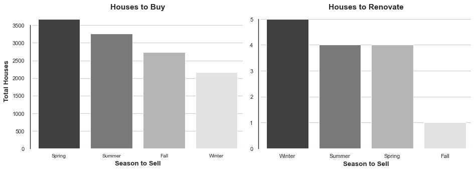

```python
# figure size
fig = plt.figure(figsize=(12,8), dpi=80)
ax = fig.add_gridspec(2, 2) # creates grids

# creating bars
with sns.axes_style('white'):
    fig.add_subplot(ax[0, 0])
    sns.countplot(data=houses_to_buy,
                  x='sell_season',
                  palette='Greys_r',
                  order = houses_to_buy['sell_season'].value_counts().index)

    # setting up style
    sns.despine(top=True, bottom=True, offset=5)
    plt.grid(axis='y')

    # setting up axis and title
    plt.title('Houses to Buy', fontsize=14, fontweight='bold')
    plt.xlabel('Season to Sell', fontsize=12, fontweight='bold')
    plt.ylabel('Total Houses', fontsize=12, fontweight='bold')
    plt.rcParams['xtick.labelsize'] = 10
    plt.rcParams['ytick.labelsize'] = 10

# creating bars
with sns.axes_style('white'):
    fig.add_subplot(ax[0, 1])
    sns.countplot(data=houses_to_renovate,
                  x='sell_season',
                  palette='Greys_r',
                  order = houses_to_renovate['sell_season'].value_counts().index)

    # setting up style
    sns.despine(top=True, bottom=True, offset=5, trim=True)
    plt.grid(axis='y')

    # setting up axis and title
    plt.title('Houses to Renovate', fontsize=14, fontweight='bold')
    plt.xlabel('Season to Sell', fontsize=12, fontweight='bold')
    plt.ylabel('')
    plt.rcParams['xtick.labelsize'] = 10
    plt.rcParams['ytick.labelsize'] = 10

# plotting and saving the plot
plt.savefig("plots/total-sales-by-season.png", dpi=300, bbox_inches='tight')
fig.tight_layout()
plt.show()
```

Houses to Renovate Summary

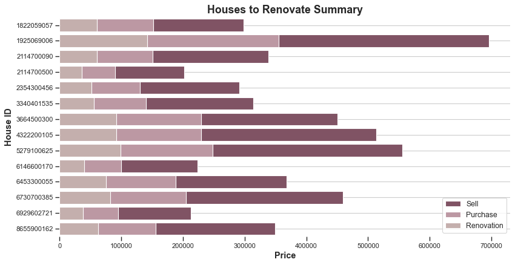

```python
# figure size
fig = plt.figure(figsize=(12,6), dpi=80)

# creating bars
sns.set_color_codes("deep")
sns.barplot(x="sell_price", y="id", data=houses_to_renovate,
            label="Sell", color="#874c62", orient='h')

sns.set_color_codes("muted")
sns.barplot(x="price", y="id", data=houses_to_renovate,
            label="Purchase", color="#c292a1", orient='h')

sns.set_color_codes("deep")
sns.barplot(x="max_renovation_outlay", y="id", data=houses_to_renovate,
            label="Renovation", color="#c8aca9", orient='h')

# setting up style
sns.set_theme(style='white')
sns.despine(left=True, right=True, top=True, bottom=True)
plt.grid(axis='y')


# setting up axis and title
plt.title('Houses to Renovate Summary', fontsize=16, fontweight='bold')
plt.xlabel('Price', fontsize=13, fontweight='bold')
plt.ylabel('House ID', fontsize=13, fontweight='bold')
plt.rcParams['xtick.labelsize'] = 10
plt.rcParams['ytick.labelsize'] = 10
plt.legend()

# saving the plot
plt.savefig("plots/houses-to-renovate-summary.png", dpi=300, bbox_inches='tight')
plt.show()
```

### 6. Conclusion

As a result of this analysis, Greener Houses has about 11840 good deals on the construction market. In addition, the company could still have other 14 opportunities if it is willing to invest on renovation prior to selling.

If the company chooses to invest only on the two more profitable regions out of the seventy available, it would still have 216 houses stated as good deals. This would represent a rate of 3 to 4 houses per month over the next 4 to 6 years, totalizing an average profit of U\$234.344,38 per house and about U\$700.000 to U\$1.000.000 per month.

Now Greener Houses is capable of making its decisions based on the market opportunities, the financial returns, and also on the company revenue available to invest on these businesses. Moreover, the best time for selling and the profits for each deal will also be available for the company to evaluate prior to the decision-making.